cas-src v4.9.0Release report · Published 9 November 2026 · 11:57 AM ET

# Every answer keeps arriving, and finished commands clear themselves.

49 changes listed across 5 areas; Tasks has the most, 26.

See every change ↓

## Release at a glance

01 / 06

**What shipped, by area**

| Area | Changes | What changed |
| --- | --- | --- |
| Commander | 6 | Supervisor answers keep reaching Commander after an MCP reconnect; Finished commands clear themselves; Recover command status after failed cancellation; Project card names clear the avatar; Project ca… |
| Sessions | 9 | Supervisor stall notices respect operator-blocked worker tasks; Resolve lane models for the chosen account; Supervisor clears follow live context pressure; Staff swept tasks across machines; Superviso… |
| Tasks | 26 | Remote target park checks; Batch QA notices follow current ownership; Target-only verifier re-dispatch; Retained branch identity; Task queues distinguish running and held work; Primary workflow findin… |
| Releases | 6 | Green trains cut themselves; Released fragment audit; Explain the changelog revision checked at close; Backfill respects frozen trains and close holds; Reuse the proven preflight executable; Keep rele… |
| Safety | 2 | Keep Claude Keychain logins in place; Captured exit-status comparisons |
| Total | 49 | 5 areas |

Source: CHANGELOG `CHANGELOG.md`, release-notes draft `docs/release-notes/2026-11-09-v4.9.0-slack.md`, GitHub `Richards-LLC/cassy` release v4.9.0; retrieved 9 November 2026 · 12:52 PM ET.

49Changes listed

48 fixed, 1 added; tests, docs, known limits and upgrade notes not counted

2GitHub issues closed

Closed from PR #1708 opening to 15 min after merge

17m 0sGreen to published

Within budget (20m 0s budget); Merge-queue CI completion to publication

16m 56sMain to published

Within budget (20m 0s budget); release PR landing on main to publication

15h 7mFirst commit to main

Over budget (30m 0s budget); the train opened 8 November

1Merge-queue runs

Runs on the final release tree before merge (run 42654298865)

Changes and GitHub issues are counted separately. A change is one titled entry in the v4.9.0 CHANGELOG section; entries under Test, Doc, Known limits, Upgrade, Migration or Operator guidance headings are listed under the hood but not counted. A GitHub issue counts when release PR #1708 or the CHANGELOG section references it and it closed between the PR opening (11:21 AM ET) and 15 minutes after its merge (11:55 AM ET). Issues are closed by hand shortly after the merge, so a report run inside that window waits for referenced issues that are still open. No release stage was blocked. No manual interventions. Not measured for this release: request to published, cut to published, lesson recurrence.

## What you can do now

02 / 06

01

### Commander stays in sync, and cleanup is tidier

#### Answers keep reaching Commander

Wasafter `/clear` and a reload of Cassy's tools, later answers silently stopped showing up in Commander.

Nowthey keep arriving, once each.

#### Finished commands clear themselves

Wasa finished command such as Reload Cassy left a result card that needed Dismiss.

Nowa short message appears and fades on its own. Failed or unconfirmed commands keep their card.

#### Project card names are readable

Nowthe name starts after the avatar and fits; the machine name gives way first.

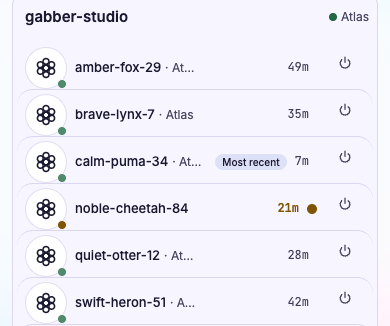

Before

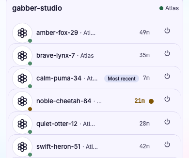

After

#### A stuck Cancel recovers

Wasa refused or timed-out Cancel left the command stuck at queued and blocked every later command.

NowCassy keeps following the command to its real outcome, and later commands work.

#### Finish cleans up after itself

WasFinish could leave background shells and servers it started still running.

Nowit stops its own background work and checks that none is left.

#### Releases start themselves when ready

Wasa release that passed every check waited for someone to start it.

NowCassy starts it once every check is green and the notes are ready.

#### Mac Claude logins stay put

Wasaccount linking could move a Claude login kept in the macOS Keychain and report it as drift.

Nowactive logins are left in place.

#### Search and memories

Wastasks made on another machine could be missing from search, and renaming a memory by title alone did not save.

Nowsearch reads the current task list and stops exact duplicates, and title-only renames save.

## Under the hood

03 / 06

01

### Release changes

#### Commander mirror

Was`/mcp` reconnect after `/clear` restored the first pane's session id, and a second registration for one pane double-mirrored.

Nowthe rebound session survives reconnect, and one transcript mirrors once.

#### Commander UI

Wasfinished commands left a result card, a refused Cancel froze the receipt at queued, and project-card names clipped or overflowed.

Nowsuccess shows a self-clearing toast, Cancel resumes outcome polling, and the who-line sizes to the avatar and ellipsizes in narrow cards.

#### Auto-cut

Wasa green train waited for a manual `scripts/release.sh`.

Nowan exact train tip with a green full-suite receipt, changelog fragments and a notes draft freezes and cuts itself. Backfill skips frozen successor trains.

#### Close gates

Wasfirst park could read an earlier failing-test commit, refusals hid paths and revisions, and filenames counted as proof claims.

Nowfirst park reads the recorded pushed tip, refusals name the path, gate and checked revision, and local summaries are not external proof.

#### Delivery identity

Washistorical branches or lane reuse could displace the current delivery, and shared upkeep invalidated sibling reviews.

Nowclose follows the recorded parked branch, recovery keeps the current receipt, and generated CODEMAP or overview upkeep keeps approvals.

#### Verification

Wasa crashed automatic verifier held its claim, a stale agent row blocked verdicts, and a target-only move re-asked an answered call.

Nowone retry replaces a crashed verifier, process liveness decides "running", and a target-only re-dispatch reuses the answer.

#### Task start and moves

Wasan epic move kept the old lane target, an empty retargeted branch could not be rebound, and linked-checkout WIP lost ownership.

Nowmatching targets follow the move, a clean empty replacement branch can be approved, and linked WIP keeps its recorded owner.

#### Tasks and queues

Wasdep_remove echoed the removed edge, `duplicate` deps acted as blocking, and startup assignments could reorder.

Nowthe receipt names the removed edge, unsupported types are refused, and startup queues keep order with Current and Held shown apart.

#### Spawn and accounts

Waslane models were resolved before the account was chosen, and Keychain Claude logins looked like link drift.

Nowmodels resolve per selected account with its registered fallback, and native Claude auth paths are preserved.

#### Notices and handoffs

Wascapacity waits woke the supervisor per worker, cached reads tripped auto-clear, and handoffs crossed machines.

Nowdisk waits share one notice, auto-clear measures the latest call, and handoffs stay within machine, project and role.

## Fixes ledger

04 / 06

GitHub issues closed with this release · 2

| Issue | Title | Closed | Area |
| --- | --- | --- | --- |
| [#1636](https://github.com/Richards-LLC/cassy/issues/1636) | task update/create report 'Updated priority' but a finding's derived priority silently overrides the requested one | 9 November 2026 · 11:40 AM ET | Tasks |
| [#1665](https://github.com/Richards-LLC/cassy/issues/1665) | Supervisor auto-clear budget sums cumulative cache-read input per wake; a fresh supervisor trips 1M after ~15 tool calls | 9 November 2026 · 11:40 AM ET | Sessions |

Referenced and still open at retrieval, so not counted: [#1502](https://github.com/Richards-LLC/cassy/issues/1502).

## Install

05 / 06

```
cas update --yes --version 4.9.0
```

Release assets

| Asset | Digest | Size |
| --- | --- | --- |
| cas-aarch64-apple-darwin.tar.gz | sha256:64ad36222a61f10be6b0864dd992b7bf2b1c44f262a3eee7040d1f24749250ae | 41730269 |
| cas-x86_64-unknown-linux-gnu.tar.gz | sha256:97e63e663fd738efaf70c9e028c0459a08fe83ca24a129af8c51f46f1daf5cf1 | 47529508 |
| hub-deployment.json | sha256:e142e655e6f69d7f962b982a7582cf471bb62f46ba1f374fd434da0a80596a58 | 1178 |

## Evidence and scope

06 / 06

Retrieved: 9 November 2026 · 12:52 PM ET.

Source: CHANGELOG `CHANGELOG.md`, release-notes draft `docs/release-notes/2026-11-09-v4.9.0-slack.md`, GitHub `Richards-LLC/cassy` release v4.9.0; retrieved 9 November 2026 · 12:52 PM ET.

Areas were assigned by hand from each change's CHANGELOG heading; placement by title words had misfiled Commander and verifier changes. The five areas and their order are the generator's.

Release PR: https://github.com/Richards-LLC/cassy/pull/1708 (merged 9 November 2026 · 11:40 AM ET).

Release-notes draft: `docs/release-notes/2026-11-09-v4.9.0-slack.md`.

CHANGELOG source: `CHANGELOG.md`.

GitHub release: https://github.com/Richards-LLC/cassy/releases/tag/v4.9.0 (published 9 November 2026 · 11:57 AM ET from tag v4.9.0 at commit 121690ea7; release commit 64bd2f9bc; main at c03b879c9; Linux x86_64 and macOS ARM64 archives attached).

Release receipt (relative to `~/.cas/artifacts`): `cassy-ee10031b42e3c2024023c076dfb2edd8118e39b8baee6f0832367b9e8ef4c205/cas-b108/latency/release-latency.receipt`.

### Pipeline latency

Gate green at 11:40:21 AM ET (merge-queue run 42654298865), main landed at 11:40:25 AM ET and the release published at 11:57:21 AM ET: 1020 s from green and 1016 s from main, against a 1200 s budget. First commit to main took 54446 s against a 1800 s budget, per the published receipt (`release-published-receipt.sh`), which decides the counted child; the latency receipt measured 53057 s. Stage timings are unavailable: the latency receipt records no STAGE_SECS, and request-to-published and cut-to-published were not measured.

### Limits

- First commit to main was over budget, so this shows a publication within budget, not a fast train.
- Issue #1502 is referenced by the CHANGELOG but was still open at retrieval, so it is listed and not counted.

No source warnings.